# Jan14 to Jan 16 Life Expectancy and GDP

Joseph Holler

2025-01-20

# Install and load packages

Install required packages

```r
#install.packages("here")
#install.packages("tidyverse")
#install.packages("rvest")
#install.packages(c("gganimate", "gifski", "av"))
#install.packages("treemapify")
```

Load packages

Load Life expectancy data

Make a line graph of life expectancy for South Africa

THis comes in wide-format data

```r
life_expectancy |>
  filter(country == "South Africa")
```

```
## # A tibble: 1 × 302
##   country  `1800` `1801` `1802` `1803` `1804` `1805` `1806` `1807` `1808` `1809`
##   <chr>     <dbl>  <dbl>  <dbl>  <dbl>  <dbl>  <dbl>  <dbl>  <dbl>  <dbl>  <dbl>
## 1 South A…   33.5   33.5   33.5   33.5   33.5   33.5   33.5   33.5   33.5   33.5
## # ℹ 291 more variables: `1810` <dbl>, `1811` <dbl>, `1812` <dbl>, `1813` <dbl>,
## #   `1814` <dbl>, `1815` <dbl>, `1816` <dbl>, `1817` <dbl>, `1818` <dbl>,
## #   `1819` <dbl>, `1820` <dbl>, `1821` <dbl>, `1822` <dbl>, `1823` <dbl>,
## #   `1824` <dbl>, `1825` <dbl>, `1826` <dbl>, `1827` <dbl>, `1828` <dbl>,
## #   `1829` <dbl>, `1830` <dbl>, `1831` <dbl>, `1832` <dbl>, `1833` <dbl>,
## #   `1834` <dbl>, `1835` <dbl>, `1836` <dbl>, `1837` <dbl>, `1838` <dbl>,
## #   `1839` <dbl>, `1840` <dbl>, `1841` <dbl>, `1842` <dbl>, `1843` <dbl>, …
```

```r
life_expectancy_sa <- life_expectancy |>
  filter(country == "South Africa") |>
  pivot_longer(-country,
               names_to = "Year",
               values_to = "LifeExpectancy") |>
  mutate(Year_Numeric = as.numeric(Year))

life_expectancy_sa
```

```
## # A tibble: 301 × 4
##    country      Year  LifeExpectancy Year_Numeric
##    <chr>        <chr>          <dbl>        <dbl>
##  1 South Africa 1800            33.5         1800
##  2 South Africa 1801            33.5         1801
##  3 South Africa 1802            33.5         1802
##  4 South Africa 1803            33.5         1803
##  5 South Africa 1804            33.5         1804
##  6 South Africa 1805            33.5         1805
##  7 South Africa 1806            33.5         1806
##  8 South Africa 1807            33.5         1807
##  9 South Africa 1808            33.5         1808
## 10 South Africa 1809            33.5         1809
## # ℹ 291 more rows
```

graph the data

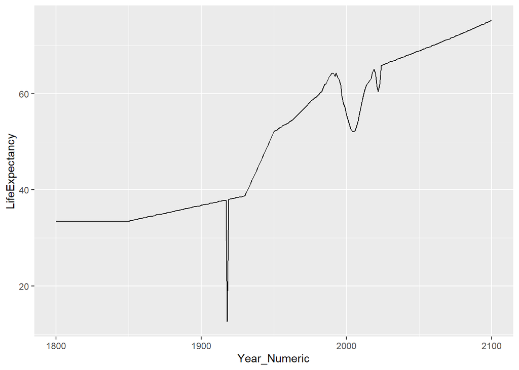

```r
life_expectancy_sa |>
  ggplot() +
  geom_line(aes(x = Year_Numeric, y = LifeExpectancy))
```

## Make the same graph but for three random countries

```r
random3 <- life_expectancy |>
  select(country) |>
  sample_n(3)

random3
```

```
## # A tibble: 3 × 1
##   country
##   <chr>
## 1 Burkina Faso
## 2 Kuwait
## 3 Dominican Republic
```

```r
life_expectancy_random3 <- life_expectancy |>
  filter(country %in% random3$country) |>
  pivot_longer(-country,
               names_to = "Year",
               values_to = "LifeExpectancy") |>
  mutate(Year_Numeric = as.numeric(Year))

life_expectancy_random3
```

```
## # A tibble: 903 × 4
##    country      Year  LifeExpectancy Year_Numeric
##    <chr>        <chr>          <dbl>        <dbl>
##  1 Burkina Faso 1800            29.2         1800
##  2 Burkina Faso 1801            29.2         1801
##  3 Burkina Faso 1802            29.2         1802
##  4 Burkina Faso 1803            29.2         1803
##  5 Burkina Faso 1804            29.2         1804
##  6 Burkina Faso 1805            29.2         1805
##  7 Burkina Faso 1806            29.2         1806
##  8 Burkina Faso 1807            29.2         1807
##  9 Burkina Faso 1808            29.2         1808
## 10 Burkina Faso 1809            29.2         1809
## # ℹ 893 more rows
```

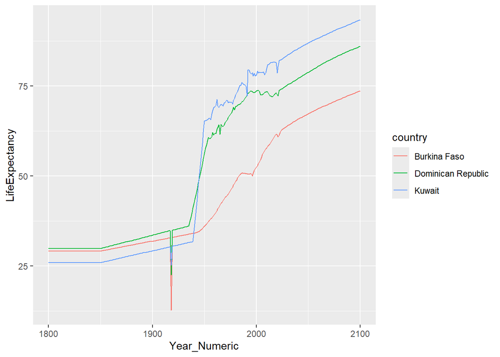

```r
life_expectancy_random3 |>
  ggplot() +
  geom_line(aes(x = Year_Numeric, y = LifeExpectancy, color=country))
```

Filter for life expectancy of zero. Did we ever complete this inclass?

```r
life_expectancy <- life_expectancy |>
  filter(country %in% random3$country) |>
  pivot_longer(-country,
               names_to = "Year",
               values_to = "LifeExpectancy") |>
  mutate(Year_Numeric = as.numeric(Year))

life_expectancy_random3
```

```r
gdp <- read_csv(here("data_public", "gdp_pcap.csv"))
```

Look out, there are `k`’s in the data for 1,000! We should replace `k` with `000` and `.` with nothing.

```r
#gdp_long <- gdp |>
#  pivot_longer
```

Check out stringr cheat sheet! Test case for `10k`

```r
str_extract("10k", "0123456789")
```

```
## [1] NA
```

```r
as.numeric(str_remove("10k", "k")) * 1000
```

```
## [1] 10000
```

Try out the conversion

```r
testconversion <- gdp |>
  mutate(`1800` = case_when(
    str_detect(`1800`, "k") ~ as.numeric(str_remove(`1800`, "k")) * 1000,
    !str_detect(`1800`, "k") ~ as.numeric(`1800`),
    str_detect(`1901`, "k") ~ as.numeric(str_remove(`1901`, "k")) * 1000,
    !str_detect(`1901`, "k") ~ as.numeric(`1901`)
  ))
```

Ok, what were those NAs about, and can we find a better way to do this compared to copying and pasting code.

# apply a function to many columns simultaneously

```r
gdp_numeric <- gdp |>
  select(-country) |>
  mutate_all(~case_when(
    str_detect(.x, "k") ~ as.numeric(str_remove(.x, "k")) * 1000,
    !str_detect(.x, "k") ~ as.numeric(.x)
  )) |>
  cbind(country = gdp$country)
na_rows <- gdp_numeric[!complete.cases(gdp_numeric), ]
```

Ok, now pivot

```r
gdp_long <- gdp_numeric |>
  pivot_longer(-country,
               names_to = "Year",
               values_to = "GDP_Per_Capita") |>
  mutate(Year = as.numeric(Year))
```

And graph

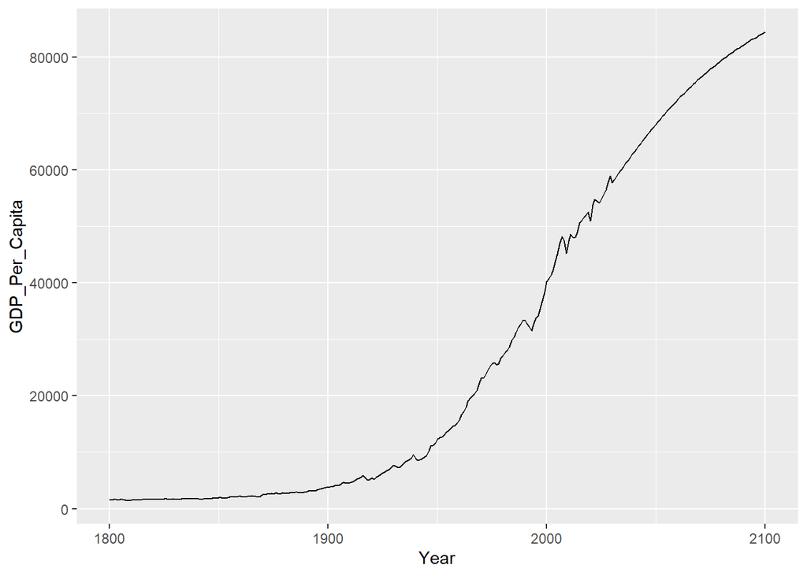

```r
gdp_long |>
  filter(country == "Sweden") |>
  ggplot() +
  geom_line(aes(x = Year, y = GDP_Per_Capita))
```

# Join the life expectancy data together with income data

`gdp_long` needs to be combined with `life_expectancy`

Save the long form of life expectancy

```r
life_expectancy_long <- life_expectancy |>
    pivot_longer(-country,
               names_to = "Year",
               values_to = "LifeExpectancy") |>
  mutate(Year = as.numeric(Year))
```

Now join them!

```r
life_gdp <- life_expectancy_long |>
  left_join(gdp_long, by = c("country", "Year"))
```

Graph a specific country and year

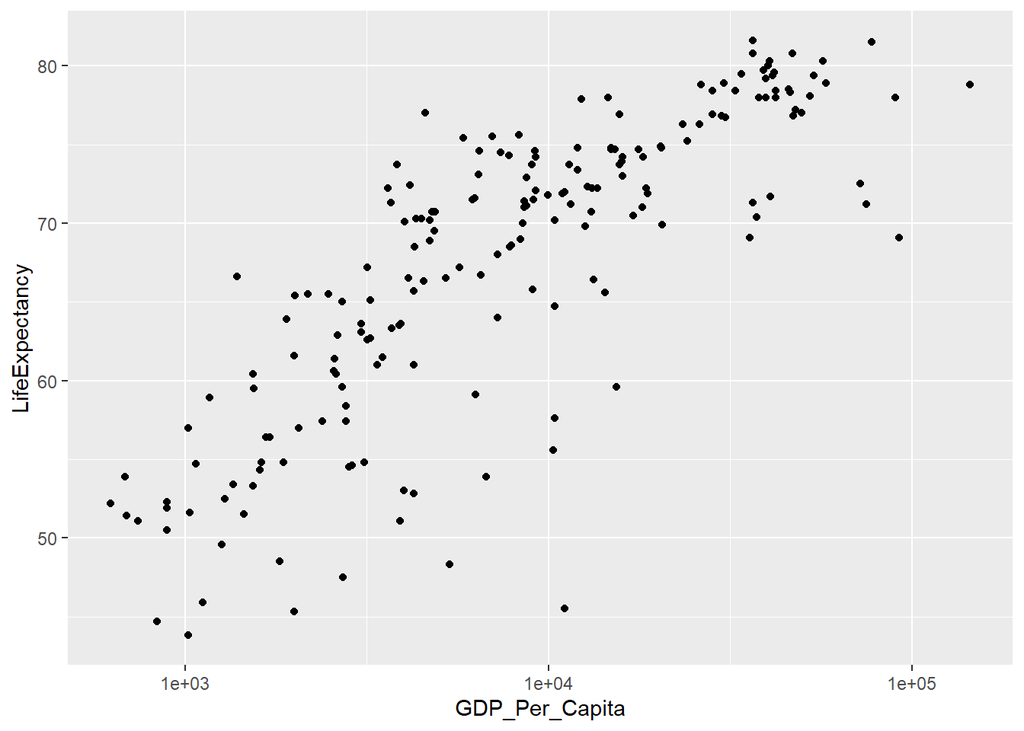

```r
life_gdp |>
  filter(Year == 2000) |>
  ggplot() +
  geom_point(aes(x = GDP_Per_Capita, y = LifeExpectancy)) +
  scale_x_log10()
```

# Jan 16 Load Joined Data

```r
pop_gdp_le <- read_csv(here("data_public", "Pop_GDP_LE_data.csv"))
```

## Size points by population

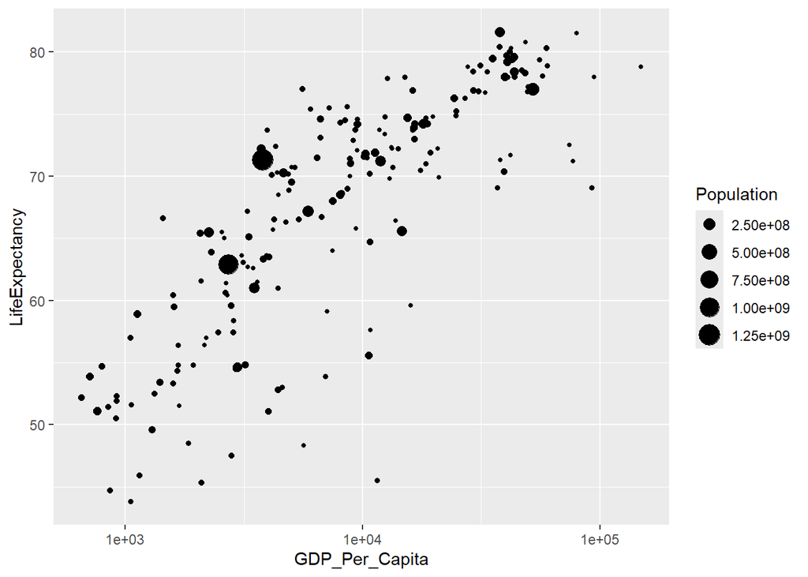

```r
pop_gdp_le |>
  filter(Year == 2000) |>
  ggplot() +
  geom_point(aes(x = GDP_Per_Capita,
                 y = LifeExpectancy,
                 size = Population)
             ) +
  scale_x_log10()
```

## Web scrape region data

so that we can color the points by region.

Search “country by region plain text”

https://statisticstimes.com/geography/countries-by-continents.php

Save the table to cSV file

```r
write_csv(region_data, here("data_public", "region_data.csv"))
```

Load region table from CSV file

```r
region_data <- read_csv(here("data_public", "region_data.csv"))

region_data
```

```
## # A tibble: 249 × 7
##       No `Country or Area`   `ISO-alpha3 Code` `M49 Code` `Region 1`  `Region 2`
##    <dbl> <chr>               <chr>                  <dbl> <chr>       <chr>
##  1     1 Afghanistan         AFG                        4 Southern A… <NA>
##  2     2 Åland Islands       ALA                      248 Northern E… <NA>
##  3     3 Albania             ALB                        8 Southern E… <NA>
##  4     4 Algeria             DZA                       12 Northern A… <NA>
##  5     5 American Samoa      ASM                       16 Polynesia   <NA>
##  6     6 Andorra             AND                       20 Southern E… <NA>
##  7     7 Angola              AGO                       24 Middle Afr… Sub-Sahar…
##  8     8 Anguilla            AIA                      660 Caribbean   Latin Ame…
##  9     9 Antarctica          ATA                       10 Antarctica  <NA>
## 10    10 Antigua and Barbuda ATG                       28 Caribbean   Latin Ame…
## # ℹ 239 more rows
## # ℹ 1 more variable: Continent <chr>
```

```r
all_country_data <- pop_gdp_le |>
  left_join(
    region_data |> select(`Country or Area`, Continent), by = c("country" = "Country or Area"))
```

You can disambiguate functions using `::`, e.g. `dplyr::select` to specify you want the `select` function specifically from the `dplyr` package

# Life expectancy, GDP and Region

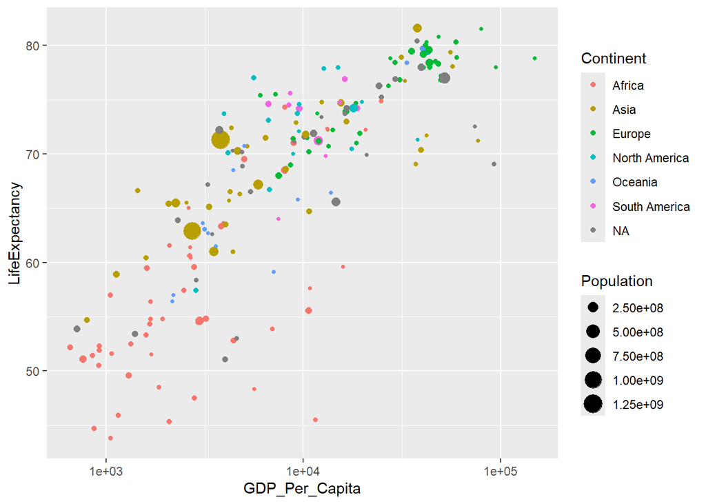

```r
all_country_data |>
  filter(Year == 2000) |>
  ggplot() +
  geom_point(
    aes(
      x = GDP_Per_Capita,
      y = LifeExpectancy,
      size = Population,
      color = Continent
    )
  ) +
  scale_x_log10()
```

There were some missing continent data!

Let’s inspect data with missing continent data.

```r
all_country_data |>
  filter(Year == 2000, is.na(Continent))
```

```
## # A tibble: 29 × 6
##    country               Year GDP_Per_Capita LifeExpectancy Population Continent
##    <chr>                <dbl>          <dbl>          <dbl>      <dbl> <chr>
##  1 UAE                   2000          92400           69.1    3280000 <NA>
##  2 Bolivia               2000           5390           66.5    8590000 <NA>
##  3 Brunei                2000          74300           72.5     334000 <NA>
##  4 Cote d'Ivoire         2000           4000           51.1   16800000 <NA>
##  5 Congo, Dem. Rep.      2000            707           53.9   48600000 <NA>
##  6 Congo, Rep.           2000           4580           53      3130000 <NA>
##  7 Cape Verde            2000           4370           70.3     458000 <NA>
##  8 Czech Republic        2000          24900           75.2   10200000 <NA>
##  9 Micronesia, Fed. St…  2000           3450           62.6     112000 <NA>
## 10 UK                    2000          39800           78     58900000 <NA>
## # ℹ 19 more rows
```

We are missing a lot of countries because of inconsistent spelling. So, Why not use ISO codes!?!

# Animation

Transitions allow you to animate by different variables By default, gganimate makes 100 frames. Themes help style the graphs!

Let’s have one code block to tinker with the graph design, and then a second block to tinker with the animation

### Graph all years

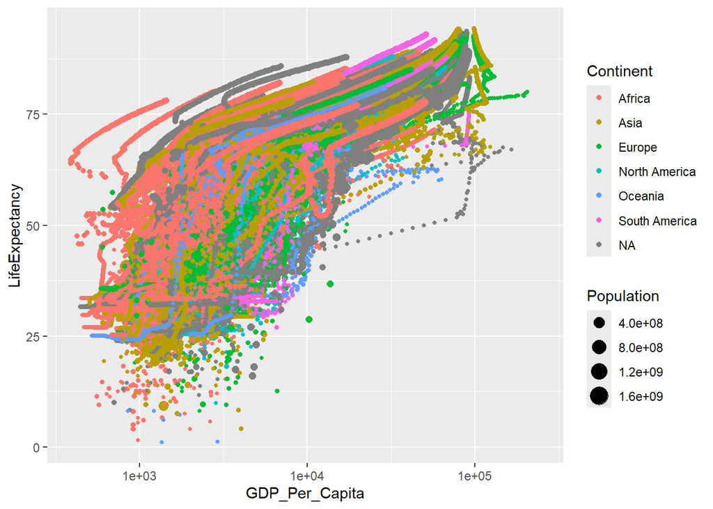

```r
all_country_data |>
  ggplot() +
  geom_point(aes(x = GDP_Per_Capita,
                 y = LifeExpectancy,
                 size = Population,
                 color = Continent)
             ) +
  scale_x_log10()
```

## Create the animation

```r
animation1 <- all_country_data |>
  ggplot() +
  geom_point(
    aes(
      x = GDP_Per_Capita,
      y = LifeExpectancy,
      size = Population,
      color = Continent
    )
  ) +
  geom_text(x = 100000, y = 13, label = "{frame_time}") +
  scale_x_log10() +
  ggtitle("{frame_time}") +

  theme(
    panel.background = element_rect(fill = "lightblue",
                                    colour = "lightblue",
                                    linewidth = 0.5, linetype = "solid"),
    panel.grid.major = element_line(size = 0.5, linetype = 'solid',
                                    colour = "white"),
    panel.grid.minor = element_line(size = 0.25, linetype = 'solid',
                                    colour = "white")
  ) +
  transition_time(Year)
```

Render the animation

```r
anim_speed <- 3
anim_duration <- (max(all_country_data$Year) - min(all_country_data$Year) + 1) / anim_speed

animate(animation1,
        fps = anim_speed,
        duration = anim_duration)
```

save the animation

```r
anim_save(here("scripts", "life_gdp.gif")
```

## Rendered Animation

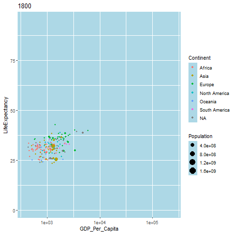

Life GDP Animation

## Animate a bar chart

```r
bar_animation <- all_country_data |>
  filter(country %in% c("Mexico", "UK", "Morocco")) |>
  ggplot() +
  geom_col(aes(y = country, x = Population)) +
  transition_time(Year)

animate(bar_animation, nframes = 300)
```

Save bar chart animation

```r
anim_save(here("scripts", "bar_anim.gif"))
```

[figure not shown]

Bar Chart Animation

## Make a tree map

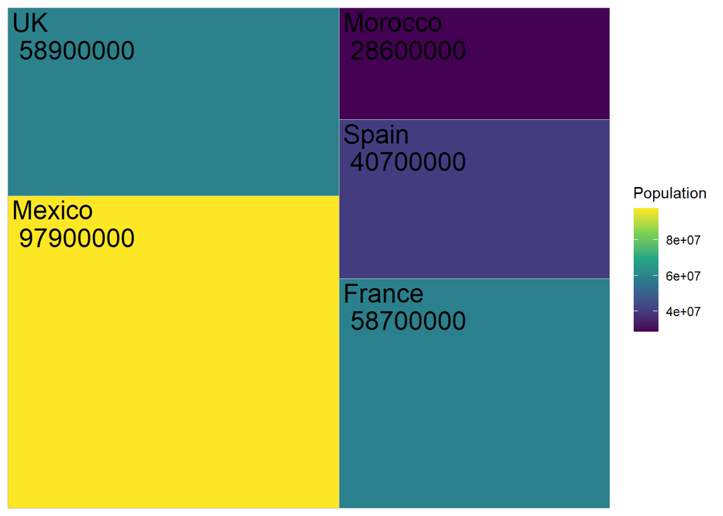

```r
all_country_data |>
  filter(Year == 2000) |>
  filter(country %in% c("Mexico", "UK", "Morocco", "France", "Spain")) |>
  ggplot(aes(area = Population,
             fill = Population,
             label = paste(country, "\n", Population))) +
  geom_treemap() +
  geom_treemap_text() +
  scale_fill_viridis_c()
```

### Animate a tree map

```r
tree_animation <- all_country_data |>
  filter(country %in% c("Mexico", "UK", "Morocco", "France", "Spain")) |>
  ggplot(aes(area = Population,
             fill = Population,
             label = paste(country, "\n", Population))) +
  geom_treemap() +
  geom_treemap_text() +
  transition_time(Year) +
  scale_fill_viridis_c()

animate(tree_animation, nframes = 300)
```

Save tree map animation

```r
anim_save(here("scripts", "tree_anim.gif"))
```

[figure not shown]